# Revisiting “Annotation of phenotypes using ontologies” with agentic curation

### James P. Balhoff<sup>1</sup>, Hilmar Lapp<sup>2</sup>

##### <sup>1</sup> Renaissance Computing Institute, University of North Carolina at Chapel Hill; <sup>2</sup> Neuromatch

# Introduction

The vast majority of phenotypic descriptions in the scientific literature are expressed using natural language, including the comparative character matrices underpinning phylogenetic analyses of morphological change. The [Phenoscape project](https://kb.phenoscape.org/) spearheaded the application of structured, formal annotations to these datasets using bio-ontologies, facilitating integration and semantic query across multiple studies in a common knowledgebase.

[Dahdul et al. (2015)](https://doi.org/10.1093/database/bay110) analyzed annotation consistency across human curators and compared the performance of an automated NLP tool, *Semantic CharaParser*, against a Gold Standard dataset using ontology-based semantic similarity metrics. Automated curation would greatly accelerate large-scale annotation, which is labor intensive.

# Evolutionary Character States

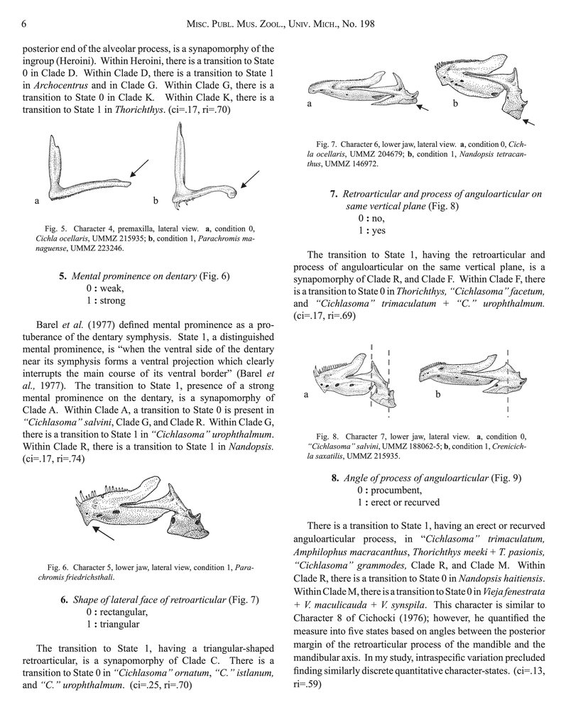

Figure 1: Character states from Chakrabarty 2007. *A morphological phylogenetic analysis of Middle American cichlids with special emphasis on the section ‘Nandopsis’ sensu Regan.* UMMZ 198 1-30.

In comparative morphology, organisms are described using **characters** (observable anatomical features) and **states** (the specific forms a character takes across taxa). For example, a character might be “shape of the caudal fin” with states such as “forked” or “rounded.”

Phenoscape annotates character states with ontology terms using an Entity–Quality (EQ) model, enabling compatibility with model organism databases describing developmental phenotypes, linking free-text morphological observations to formal knowledge representations.

# Original Methodology

**Human Curators.** Three curators (WD, AD, NI) each EQ-annotated the same set of character states in two rounds, using the Phenex annotation software: a Naive Round, working with only the character state text, and a subsequent Knowledge Round, with full access to the source publication and other literature.

**Automated Annotations.** Semantic CharaParser was used to generate automated annotations from the same character descriptions.

## Ontology-based Comparison Metrics

Because annotations reference ontology terms, comparison is not binary but graded: terms sharing more ontological ancestors are more semantically similar. Ancestor sets were computed via the ELK OWL reasoner over a merged ontology (UBERON, PATO, BSPO, GO) enriched with materialized relational expressions (e.g., *part_of*). Four complementary metrics were used:

**SimJ** (Jaccard similarity): ratio of shared to total ancestors — $|Anc(A) \cap Anc(B)| / |Anc(A) \cup Anc(B)|$.

**NIC** (Normalized Information Content): identifies the Most Informative Common Ancestor, weighting by term specificity rather than treating all ancestors equally.

**Partial Precision (PP)** and **Partial Recall (PR)** account for imperfect matches, based on ontology semantics. *PP* measures the proportion of the semantics annotated by the Gold Standard that is retrieved by the test curator relative to the number of test curator annotations. *PR* measures the proportion of semantics that are retrieved by the test curator relative to the number of Gold Standard annotations. *PP* will decrease due to extra annotations by the test curator that are dissimilar from those in the Gold Standard, while *PR* will decrease due to extra annotations in the Gold Standard that are lacking from the test curator. Both use SimJ to measure semantic similarity and are computed at the character-state level rather than the individual EQ annotation level.

# Agentic Annotation

We extended the original study by introducing AI agent curators (Claude Opus 4.6, Claude Sonnet 4.6, GPT 5.4, and GPT 5.4 Mini) as additional participants, evaluated using the same metrics and Gold Standard.

## Agent Workspace

Each AI agent is launched within a self-contained workspace:

```
ai-annotation/
├── AGENTS.md
├── input/
│   ├── characters/         ← per-character TSVs
│   ├── papers/             ← source publication PDFs
│   ├── ontologies/         ← UBERON, PATO, BSPO, GO
│   └── annotation_guide.md
├── output/                 ← agent annotation results
├── scripts/
│   └── validate_annotations.scala
└── .agents/
    └── skills/
        └── phenotype-eq-annotation/
            └── SKILL.md
```

Emulating the “knowledge round” of human curation, the agents were provided with the characters and states for a single publication at a time. They were free to read the source publication PDF and to consult the *Phenoscape Guide to Character Annotation* in Markdown format. The mechanics of performing EQ annotation and searching source ontologies were outlined in the *phenotype-eq-annotation* skill document (following the **Agent Skills** format: https://agentskills.io/home). The skill also instructed the agent to make use of a validation script to verify their output structure and syntax and to guard against term identifier hallucinations. Agents were prompted to begin annotation of all the character files in the input folder using the *phenotype-eq-annotation* skill.

# Results

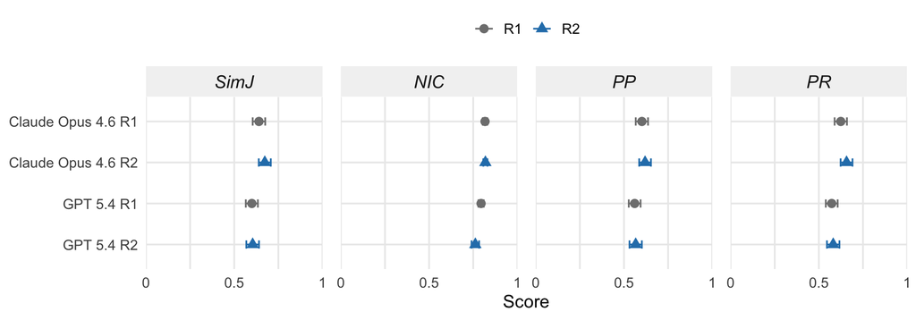

Figure 2: Mean similarity scores (with 95% CI) for AI annotators vs. the Gold Standard (all 203 characters). After a first round of annotation by Claude Opus 4.6 and GPT 5.4, a review of the first 50 characters was used to refine the instructions and validation script.

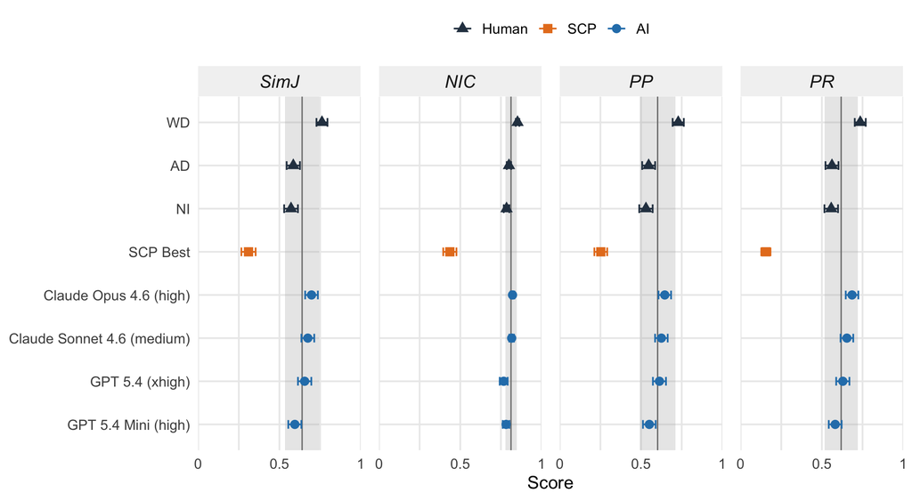

Figure 3: Mean similarity scores (with 95% CI) for each annotator vs. the Gold Standard (characters 51–203 only; 344 character states). Shaded band shows human curator mean ± 1 SD. Compared annotators are knowledge round human curators (WD, AD, NI), Semantic CharaParser (SCP), and AI agents using the refined environment.

# Discussion

The AI agents all fall within the range of human variability, with the two Anthropic Claude models nearing the best human performance. Incorporation of agentic workflows would greatly increase feasibility of large-scale structured annotation of comparative free text data.

# Acknowledgments

Thanks to J. Garcia for helpful feedback and to the other authors of the original study W. Dahdul, P. Manda, H. Cui, A. Dececchi, N. Ibrahim, T. Vision, and P. Mabee.

- **Dahdul et al. (2015).** https://doi.org/10.1093/database/bay110
- **Code.** https://github.com/phenoscape/goldstandard
- **Data.** https://zenodo.org/records/1345307

This work was supported by the [Imageomics Institute](https://imageomics.org), which is funded by the NSF Harnessing the Data Revolution program, [award #2118240](https://www.nsf.gov/awardsearch/showAward?AWD_ID=2118240).